# Análisis Exploratorio de Datos

Inés Murtagh

2022-09-12

> **“Tratamiento de dataset, análisis y gráficos”**

> Trabajo Práctico 1

El siguiente trabajo consiste en la selección y tratamiento de una base de datos, para su posterior análisis y desarrollo de un modelo predictivo. La base de datos elegida proviene del repositorio de datos de la página “Kaggle”, y consiste en información sobre los clientes de la empresa de delivery de comida @iFood, y las interacciones de cada uno de esos clientes con las campañas enviadas.

Fuente: [Kaggle](https://www.kaggle.com/datasets/rodsaldanha/arketing-campaign?select=marketing_campaign.csv)

**Objetivo**

El objetivo principal es entrenar un modelo predictivo que permita a la empresa maximizar el beneficio de la próxima campaña de marketing. Poder predecir quién responderá a una oferta de un producto de iFood, a partir de distintas características tales como: el ingreso,cantidad de hijos, cantidad de dinero gastado en diversos productos, número de compras, campañas aceptadas, etc.

Un modelo de respuesta puede proporcionar un impulso significativo a la eficiencia de una campaña de marketing al aumentar las respuestas o reducir los gastos.

```r
df <- read.table("marketing_campaign.csv", sep = ";", header = TRUE)
```

```r
glimpse(df)
```

```
## Rows: 2,240
## Columns: 29
## $ ID                  <int> 5524, 2174, 4141, 6182, 5324, 7446, 965, 6177, 485…
## $ Year_Birth          <int> 1957, 1954, 1965, 1984, 1981, 1967, 1971, 1985, 19…
## $ Education           <chr> "Graduation", "Graduation", "Graduation", "Graduat…
## $ Marital_Status      <chr> "Single", "Single", "Together", "Together", "Marri…
## $ Income              <int> 58138, 46344, 71613, 26646, 58293, 62513, 55635, 3…
## $ Kidhome             <int> 0, 1, 0, 1, 1, 0, 0, 1, 1, 1, 1, 0, 0, 1, 0, 0, 1,…
## $ Teenhome            <int> 0, 1, 0, 0, 0, 1, 1, 0, 0, 1, 0, 0, 0, 1, 0, 0, 1,…
## $ Dt_Customer         <chr> "2012-09-04", "2014-03-08", "2013-08-21", "2014-02…
## $ Recency             <int> 58, 38, 26, 26, 94, 16, 34, 32, 19, 68, 11, 59, 82…
## $ MntWines            <int> 635, 11, 426, 11, 173, 520, 235, 76, 14, 28, 5, 6,…
## $ MntFruits           <int> 88, 1, 49, 4, 43, 42, 65, 10, 0, 0, 5, 16, 61, 2, …
## $ MntMeatProducts     <int> 546, 6, 127, 20, 118, 98, 164, 56, 24, 6, 6, 11, 4…
## $ MntFishProducts     <int> 172, 2, 111, 10, 46, 0, 50, 3, 3, 1, 0, 11, 225, 3…
```

[output cut: 16 more lines]

El dataset cuenta con 2240 registros, y 29 variables, de las cuales 26 son numéricas y 3 son del tipo caracter.

*Variables de entrada*

- `AcceptedCmp1` - 1 si el cliente aceptó la oferta en la 1ª campaña, 0 en caso contrario
- `AcceptedCmp2` - 1 si el cliente aceptó la oferta en la 2ª campaña, 0 en caso contrario
- `AcceptedCmp3` - 1 si el cliente aceptó la oferta en la 3ª campaña, 0 en caso contrario
- `AcceptedCmp4` - 1 si el cliente aceptó la oferta en la 4ª campaña, 0 en caso contrario
- `AcceptedCmp5` - 1 si el cliente aceptó la oferta en la 5ª campaña, 0 en caso contrario
- `MntFishProducts` - cantidad gastada en productos pesqueros en los últimos 2 años
- `MntMeatProducts` - cantidad gastada en carne en los últimos 2 años
- `MntFruits` - cantidad gastada en frutas en los últimos 2 años
- `MntSweetProducts` - cantidad gastada en dulces en los últimos 2 años
- `MntWines` - cantidad gastada en vino en los últimos 2 años
- `NumDealsPurchases` - número de compras realizadas con descuento
- `NumCatalogPurchases` - número de compras realizadas con el catálogo
- `NumStorePurchases` - número de compras realizadas en el lugar
- `NumWebPurchases` - número de compras realizadas con la página web
- `NumWebVisitsMonth` - número de visitas al sitio web de la empresa en el último mes
- `Z_Revenue` - ingresos después de la campaña de aceptación del cliente
- `Z_CostContact` - costo de contactar a un cliente
- `Complain` - 1 if customer complained in the last 2 years
- `Recency` - number of days since the last purchase

*Variable de salida*

La variable `Response` es la variable target. Vale 1 si el cliente aceptó la oferta en la última campaña, 0 en caso contrario.

# 1 Tratamiento del Dataset

## 1.1 Dar formato

En primer lugar, es importante que la variable ID sea una variable categórica y no numérica. En el formato numerico no va a ser útil para hacer el modelo predictivo, ya que este podría interpretar que se estan enumerando los registros por orden de importancia.

```r
df$ID = as.factor(df$ID)

# chequeando que no hayan registros duplicados
dups = df %>% janitor::get_dupes("ID")
```

```
## No duplicate combinations found of: ID
```

Asegurarse que la columna de fecha esté en formato Date

```r
df$Dt_Customer = as.Date(df$Dt_Customer)

min(df$Dt_Customer)
```

```
## [1] "2012-07-30"
```

```r
max(df$Dt_Customer)
```

```
## [1] "2014-06-29"
```

El registro de los datos se encuentra en el período entre 2012 y 2014

## 1.2 Creación de nuevas variables

Una de las columnas del dataset indica la fecha de nacimiento de cada cliente. A partir de esto, se calcula la edad y se elimina dicha columna

```r
# crear variable EDAD
año = format(Sys.Date(), "%Y")
df$Age = (as.numeric(año) - df$Year_Birth)
df$Year_Birth = NULL

# obtener los dias
dias = Sys.Date() - df$Enrolment

# crear variable HIJOS
df$Children = df$Kidhome + df$Teenhome
df$Kidhome = NULL
df$Teenhome = NULL

# crear variable PURCHASES
df$Purchases = df$NumDealsPurchases + df$NumCatalogPurchases + df$NumStorePurchases + df$NumWebPurchases
df$NumDealsPurchases = NULL
df$NumCatalogPurchases = NULL
df$NumStorePurchases = NULL
df$NumWebPurchases = NULL


# crear variable TOTAL AMOUNT
df$AmountRegularProds = df$MntWines + df$MntFruits + df$MntMeatProducts + df$MntFishProducts + df$MntSweetProducts

df$AmountGoldProds = df$MntGoldProds
```

## 1.3 Eliminación de variables

```r
# NO RELEVANTE PARA EL ANALISIS
df$Z_CostContact = NULL
df$Z_Revenue = NULL
```

## 1.4 Arreglar las columnas

```r
df = df %>% mutate(Marital_Status =
                      case_when(Marital_Status == "Together" | Marital_Status == "Married" ~ "Married",
                      Marital_Status == "Alone" | Marital_Status == "Absurd" | Marital_Status == "YOLO" | Marital_Status == "Single" ~ "Single",
                      Marital_Status == "Divorced" ~ "Divorced",
                      Marital_Status == "Widow" ~ "Widow"))

df = df %>% mutate(Response = case_when(Response == 0 ~ "No", Response == 1 ~ "Yes"))

df = df %>% rename(FruitAmount = MntFruits,
                   FishAmount = MntFishProducts,
                   MeatAmount = MntMeatProducts,
                   SweetAmount = MntSweetProducts,
                   WineAmount = MntWines,
                   GoldAmount = MntGoldProds
)

df = df %>% rename(Enrolment = Dt_Customer)
```

# 2 Análisis de datos faltantes

```r
# NULOS
# Contar número de nulos por columna
sapply(df, function(x) sum(is.na(x)))
```

```
##                 ID          Education     Marital_Status             Income
##                  0                  0                  0                 24
##          Enrolment            Recency         WineAmount        FruitAmount
##                  0                  0                  0                  0
##         MeatAmount         FishAmount        SweetAmount         GoldAmount
##                  0                  0                  0                  0
##  NumWebVisitsMonth       AcceptedCmp3       AcceptedCmp4       AcceptedCmp5
##                  0                  0                  0                  0
##       AcceptedCmp1       AcceptedCmp2           Complain           Response
##                  0                  0                  0                  0
##                Age           Children          Purchases AmountRegularProds
##                  0                  0                  0                  0
##    AmountGoldProds
##                  0
```

```r
# INCOME TIENE 24

# Eliminar filas con nulos en una columna concreta
df = df[!is.na(df$Income),]
```

## 2.1 OUTLIERS

Se evaluaran los outliers de las variables numericas.

```r
dfnum = df %>% select_if(is.numeric)
```

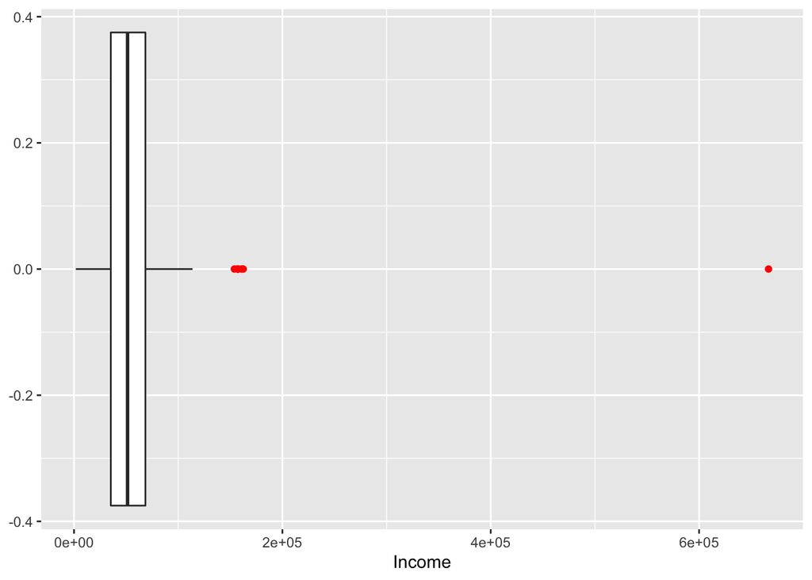

```r
# información del cliente
ggplot(df, aes(x = Income)) + geom_boxplot(outlier.colour = 'red')
```

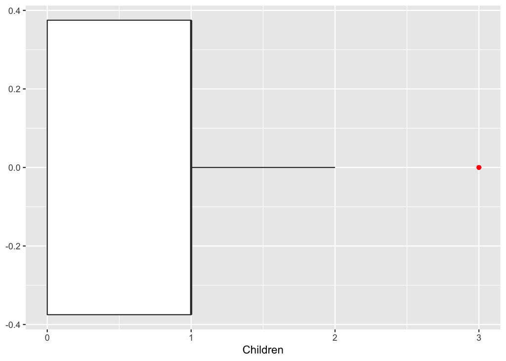

```r
ggplot(df, aes(x = Children)) + geom_boxplot(outlier.colour = 'red')
```

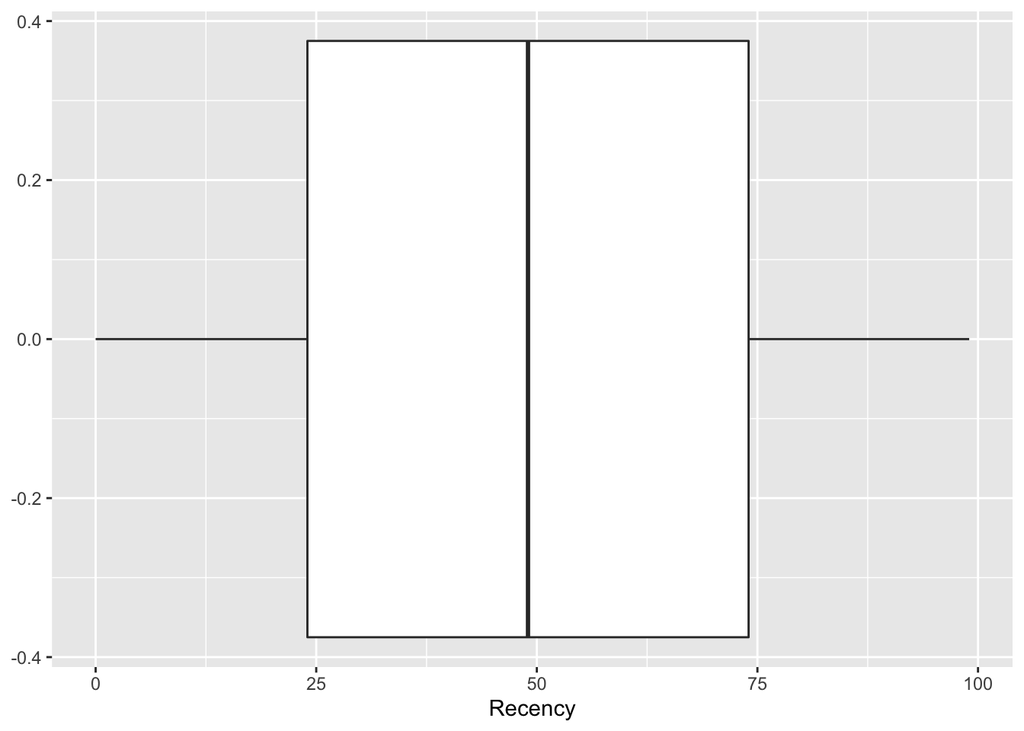

```r
ggplot(df, aes(x = Recency)) + geom_boxplot(outlier.colour = 'red')
```

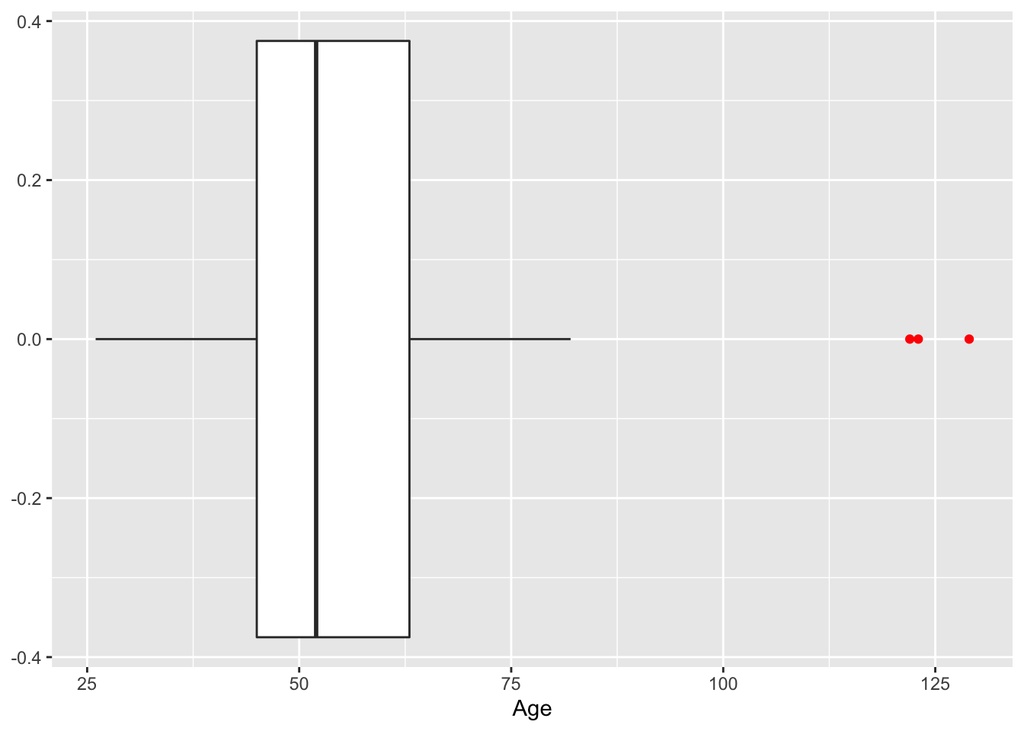

```r
ggplot(df, aes(x = Age)) + geom_boxplot(outlier.colour = 'red')
```

Al graficar el boxplot de la variable “Ingreso”, se ve que la mayoría de los datos están distribuidos hacia el lado izquierdo del gráfico, mientras que un solo punto está distribuido muy para la derecha. Es un valor atípico que ni siquiera se acerca al valor de los otras puntos.

```r
summary(df$Income)
```

```
##    Min. 1st Qu.  Median    Mean 3rd Qu.    Max.
##    1730   35303   51382   52247   68522  666666
```

```r
IQR = IQR(df$Income)
666666 > 68522 + 3*IQR
```

```
## [1] TRUE
```

```r
# es un outlier severo

registro = df %>% filter(df$Income == 666666)
registro
```

```
##     ID  Education Marital_Status Income  Enrolment Recency WineAmount
## 1 9432 Graduation        Married 666666 2013-06-02      23          9
##   FruitAmount MeatAmount FishAmount SweetAmount GoldAmount NumWebVisitsMonth
## 1          14         18          8           1         12                 6
##   AcceptedCmp3 AcceptedCmp4 AcceptedCmp5 AcceptedCmp1 AcceptedCmp2 Complain
## 1            0            0            0            0            0        0
##   Response Age Children Purchases AmountRegularProds AmountGoldProds
## 1       No  45        1        11                 50              12
```

```r
ID = 9432
df[!(df$ID == ID),]
```

[output not shown]

[output cut: 8849 more lines]

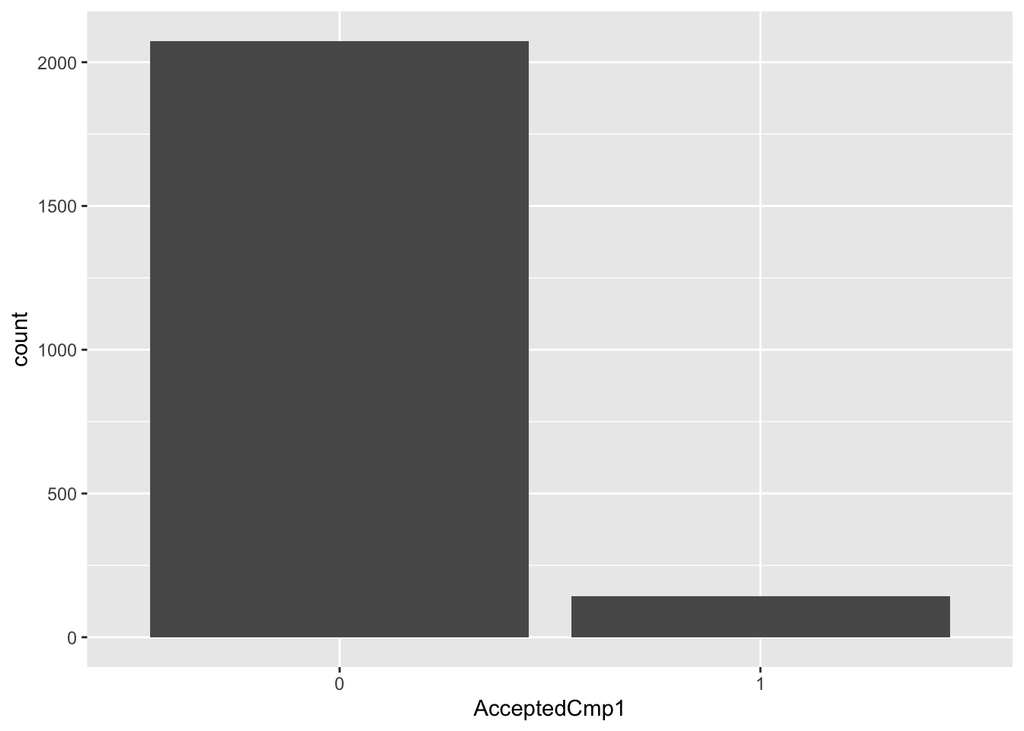

```r
df$AcceptedCmp1 = as.factor(df$AcceptedCmp1) ; ggplot(df, aes(x = AcceptedCmp1)) + geom_bar()
```

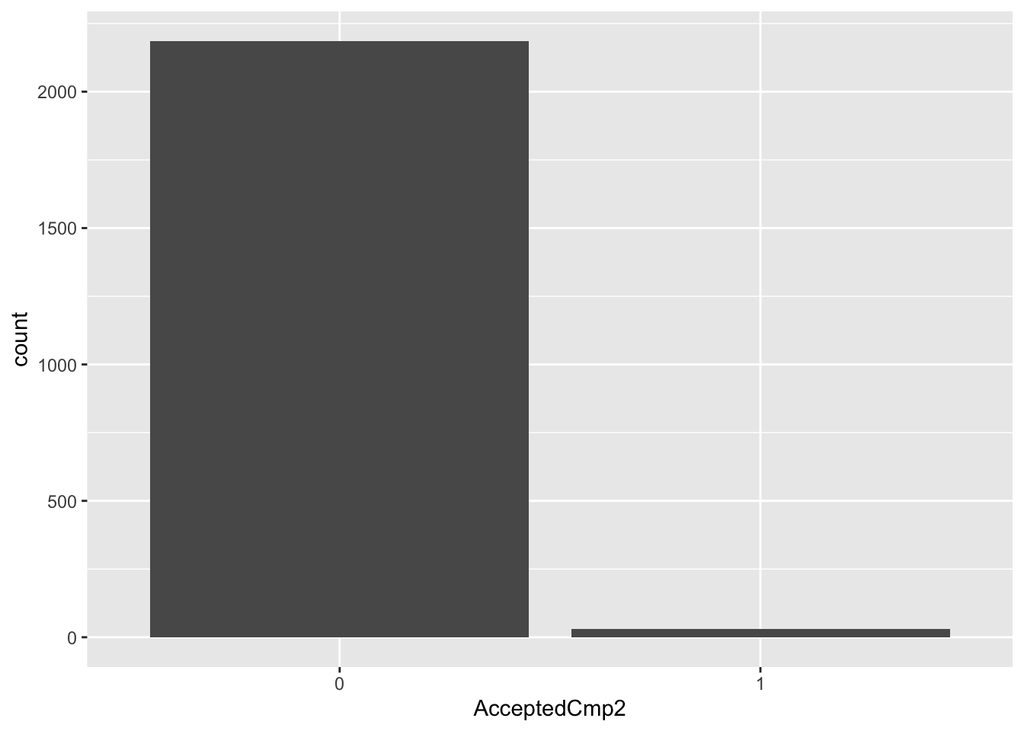

```r
df$AcceptedCmp2 = as.factor(df$AcceptedCmp2) ; ggplot(df, aes(x = AcceptedCmp2)) + geom_bar()
```

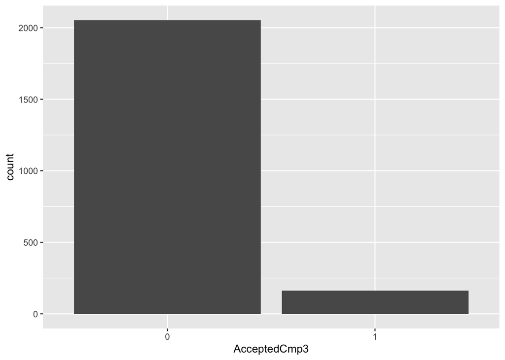

```r
df$AcceptedCmp3 = as.factor(df$AcceptedCmp3) ; ggplot(df, aes(x = AcceptedCmp3)) + geom_bar()
```

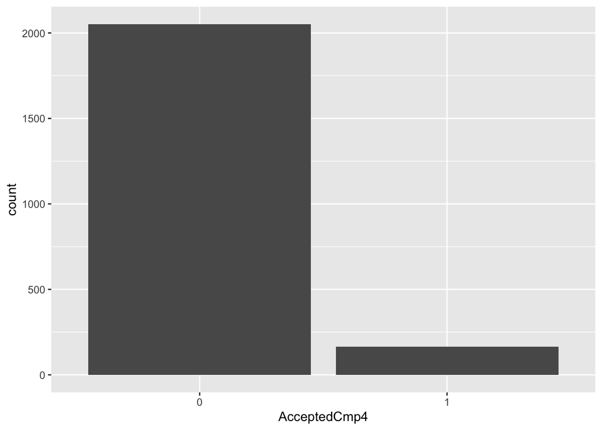

```r
df$AcceptedCmp4 = as.factor(df$AcceptedCmp4) ; ggplot(df, aes(x = AcceptedCmp4)) + geom_bar()
```

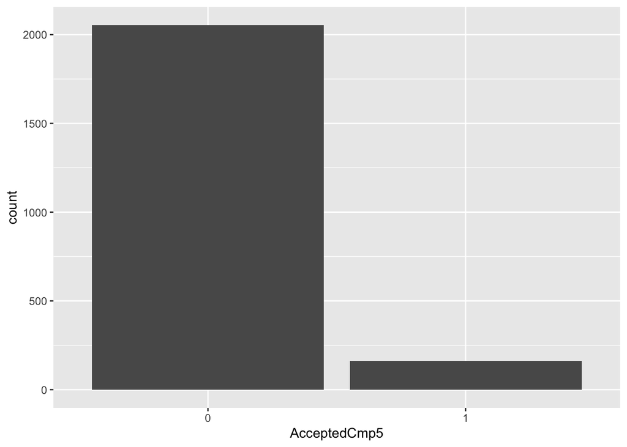

```r
df$AcceptedCmp5 = as.factor(df$AcceptedCmp5) ; ggplot(df, aes(x = AcceptedCmp5)) + geom_bar()
```

```r
df$Accepted = df$AcceptedCmp1 + df$AcceptedCmp2 + df$AcceptedCmp3 + df$AcceptedCmp4 + df$AcceptedCmp5
df$AcceptedCmp3 = NULL
df$AcceptedCmp4 = NULL
df$AcceptedCmp5 = NULL
df$AcceptedCmp1 = NULL
df$AcceptedCmp2 = NULL
```

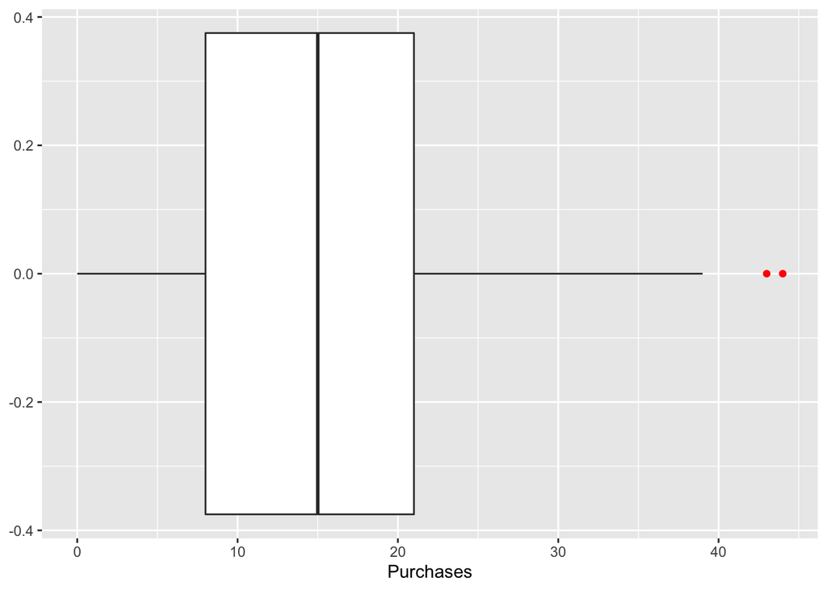

```r
# Products
ggplot(df, aes(x = Purchases)) + geom_boxplot(outlier.colour = 'red')
```

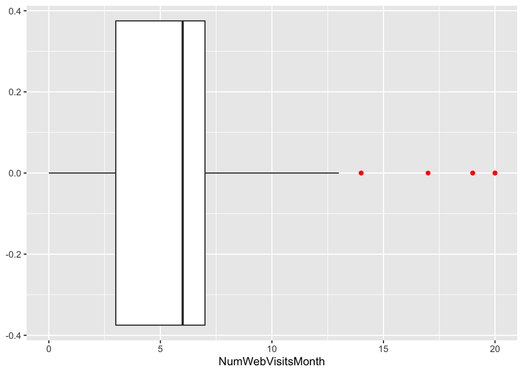

```r
ggplot(df, aes(x = NumWebVisitsMonth)) + geom_boxplot(outlier.colour = 'red')
```

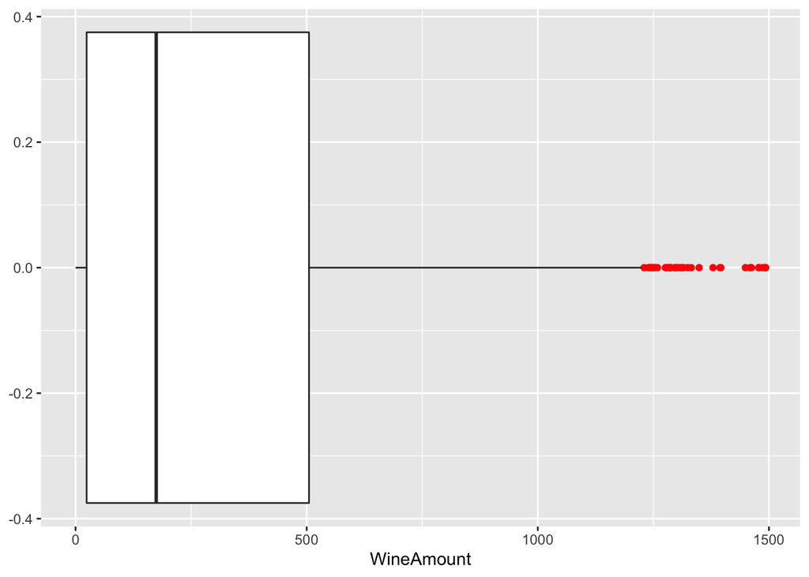

```r
ggplot(df, aes(x = WineAmount)) + geom_boxplot(outlier.colour = 'red')
```

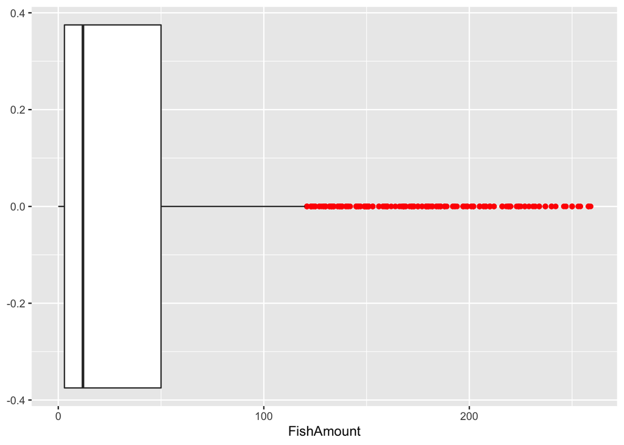

```r
ggplot(df, aes(x = FishAmount)) + geom_boxplot(outlier.colour = 'red')
```

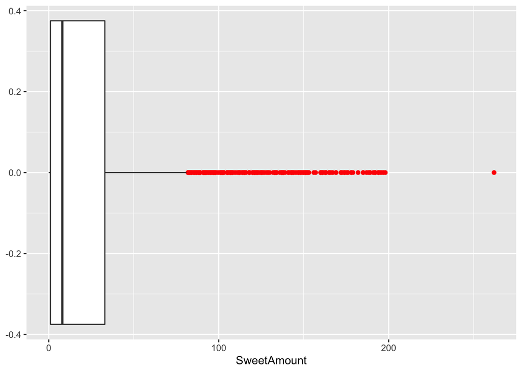

```r
ggplot(df, aes(x = SweetAmount)) + geom_boxplot(outlier.colour = 'red')
```

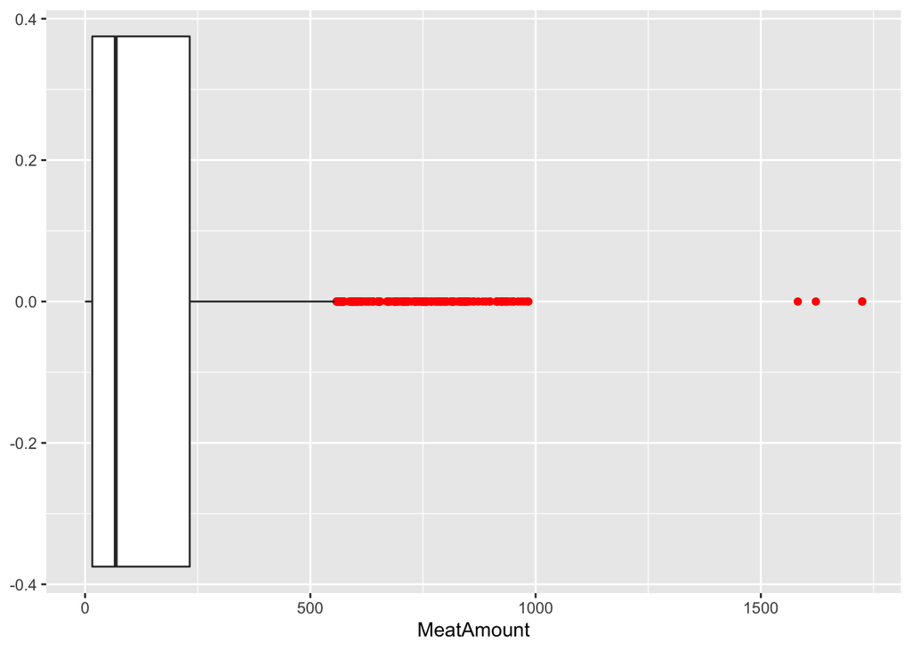

```r
ggplot(df, aes(x = MeatAmount)) + geom_boxplot(outlier.colour = 'red')
```

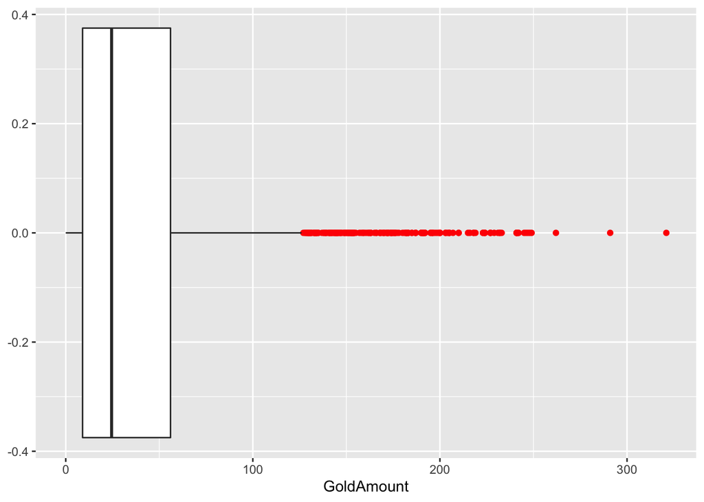

```r
ggplot(df, aes(x = GoldAmount)) + geom_boxplot(outlier.colour = 'red')
```

## 2.2 Correlaciones

Con un correlograma visualizamos la correlación entre todas las variables cuantitativas:

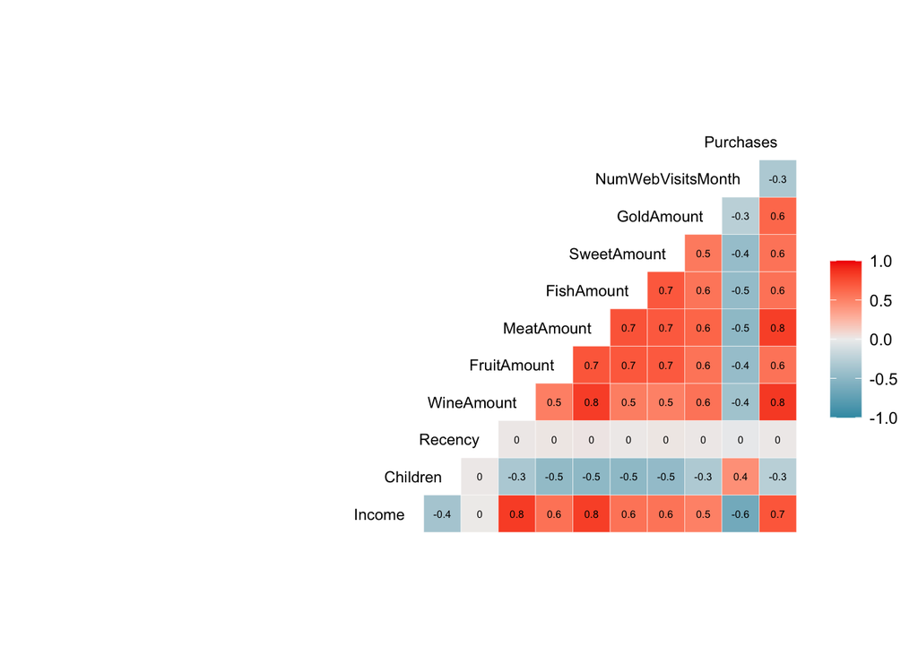

```r
dfnum = df %>% select(c(Income, Children, Recency, WineAmount, FruitAmount, MeatAmount, FishAmount, SweetAmount, GoldAmount, NumWebVisitsMonth, Purchases))

GGally::ggcorr(
  dfnum, method=c("pairwise","spearman"),
  label=T, hjust=1, label_size=2, layout.exp=10, size=3)
```

# 3 Algunos graficos